# Disconnected Landlords PSM Analysis (Streamlined)

Dmytro Kunchenko

2025-06-24

# Overview

This document outlines a Propensity Score Matching (PSM) and Ordinary Least Squares (OLS) for the “Disconnected Landlords” project. The analysis focuses on privately rented properties and uses nearest neighbor matching to compare two treatment groups (UK For-Profits and Foreign For-Profits) against a control group of properties with no corporate ownership records.

# Data Loading and Preprocessing

## Load Data

First, load the dataset. **Ensure the path to the .RData file is correct.**

```r
# Load data
# Replace with the correct path if necessary
load_path <- "~/disconnected-landlords-project/EPC_matched_combined.RData"
# For testing, if the file doesn't exist, create a dummy EPC_matched_combined
if (!file.exists(load_path)) {
  warning(paste("Data file not found at:", load_path))
} else {
  load(load_path)
}

# Ensure EPC_matched_combined is a data.table
if (!is.data.table(EPC_matched_combined)) {
  setDT(EPC_matched_combined)
}
# Display a brief summary of the loaded data
print(head(EPC_matched_combined, 3))
```

[output not shown]

[output cut: 176 more lines]

[output not shown]

```r
cat("\nDimensions of loaded data:", dim(EPC_matched_combined), "\n")
```

```
##
## Dimensions of loaded data: 1857191 141
```

## Clean `MAIN_FUEL` Variable

The `MAIN_FUEL` variable requires cleaning and standardization.

```
##
## Frequency table for MAIN_FUEL_FINAL (including NAs):
```

```
##
##     biomass        coal   dual_fuel electricity heating_oil         lpg
##         732        1952           3      245697       43091       12893
##   mains_gas        wood        <NA>
##     1435064        4138      113621
```

# Treatment and Control Definitions

The analysis is restricted to privately rented properties. The control group is defined as privately rented properties with no CCOD/OCOD record (`source == "Unknown"`).

```r
# Filter for properties that are privately rented
EPC_matched_combined <- EPC_matched_combined[TENURE == "Rented (private)"]

# Display a brief summary of the filtered data
cat("\nDimensions of data after filtering for 'Rented (private)':", dim(EPC_matched_combined), "\n")
```

```
##
## Dimensions of data after filtering for 'Rented (private)': 158104 143
```

```r
cat("\nSummary of source variable for private rentals:\n")
```

```
##
## Summary of source variable for private rentals:
```

```r
print(table(EPC_matched_combined$source, useNA = "ifany"))
```

```
##
##    CCOD    OCOD Unknown
##   67633    4686   85785
```

```r
# Define new treatment and control variables for each analysis
# A value of 1 indicates treatment, 0 indicates control, and NA for others.
# Using 1L and 0L to ensure integer type, matching NA_integer_

# Analysis 1: UK For-Profits vs. Private Landlords (No CCOD/OCOD)
EPC_matched_combined[, treat_ukforprofit := fcase(
  source == "CCOD" & grepl("For-Profit", coarse_proprietorship, ignore.case = TRUE), 1L,
  source == "Unknown", 0L,
  default = NA_integer_
)]

# Analysis 2: Foreign For-Profits vs. Private Landlords (No CCOD/OCOD)
EPC_matched_combined[, treat_foreignforprofit := fcase(
  grepl("For-Profit", coarse_proprietorship, ignore.case = TRUE) &
    (source == "OCOD" | (!is.na(country_incorporated_1) & country_incorporated_1 != "UNITED KINGDOM")), 1L,
  source == "Unknown", 0L,
  default = NA_integer_
)]

# Summary of the new treatment variables
cat("\nSummary of new treatment variables (1=Treated, 0=Control, NA=Not in comparison):\n")
```

```
##
## Summary of new treatment variables (1=Treated, 0=Control, NA=Not in comparison):
```

```r
print(summary(EPC_matched_combined[, .(treat_ukforprofit, treat_foreignforprofit)]))
```

```
##  treat_ukforprofit treat_foreignforprofit
##  Min.   :0.000     Min.   :0.00
##  1st Qu.:0.000     1st Qu.:0.00
##  Median :0.000     Median :0.00
##  Mean   :0.374     Mean   :0.04
##  3rd Qu.:1.000     3rd Qu.:0.00
##  Max.   :1.000     Max.   :1.00
##  NA's   :21021     NA's   :68309
```

# Define Common Analysis Variables

```r
# Define common variables for analysis
common_exact_vars <- c("CONSTRUCTION_AGE_BAND", "PROPERTY_TYPE", "BUILT_FORM", "MAIN_FUEL_FINAL")
common_prop_score_covs <- c("TOTAL_FLOOR_AREA", "NUMBER_HABITABLE_ROOMS", "lodgement_year")
outcome_variable <- "bad_EPC"
regression_controls <- c("TOTAL_FLOOR_AREA", "NUMBER_HABITABLE_ROOMS")
```

# Create Concatenated Categorical Variable

For use in OLS models, we create a single variable that represents the interaction of all categorical variables used for exact matching.

```r
# Create the concatenated variable using the 'common_exact_vars' object.
# This ensures that the variables used for OLS fixed effects are the same as for exact matching.
# This uses an efficient data.table approach with .SDcols
EPC_matched_combined[,
  combined_cats := do.call(paste, c(.SD, sep = "_")),
  .SDcols = common_exact_vars
]

# Convert the new column to a factor, as it will be used as a fixed effect
EPC_matched_combined[, combined_cats := as.factor(combined_cats)]

# Display a summary of the new variable
cat("\nFirst 10 values of the new 'combined_cats' variable:\n")
```

```
##
## First 10 values of the new 'combined_cats' variable:
```

```r
print(head(EPC_matched_combined$combined_cats, 10))
```

```
##  [1] England and Wales: 1900-1929_Flat_Enclosed End-Terrace_mains_gas
##  [2] England and Wales: before 1900_Bungalow_Semi-Detached_mains_gas
##  [3] England and Wales: 2003-2006_House_Mid-Terrace_mains_gas
##  [4] England and Wales: 1900-1929_Flat_Mid-Terrace_mains_gas
##  [5] England and Wales: 2007-2011_Flat_Enclosed End-Terrace_mains_gas
##  [6] England and Wales: before 1900_Flat_Mid-Terrace_mains_gas
##  [7] England and Wales: 1996-2002_Flat_End-Terrace_mains_gas
##  [8] England and Wales: 1900-1929_House_Detached_mains_gas
##  [9] England and Wales: 1900-1929_Flat_Enclosed End-Terrace_electricity
## [10] England and Wales: 1900-1929_Flat_Semi-Detached_mains_gas
## 1148 Levels: _Bungalow_Detached_electricity ... England and Wales: before 1900_Maisonette_Semi-Detached_mains_gas
```

```r
cat("\nNumber of unique categories in 'combined_cats':\n")
```

```
##
## Number of unique categories in 'combined_cats':
```

```r
print(length(levels(EPC_matched_combined$combined_cats)))
```

```
## [1] 1148
```

# Matching Procedure

Propensity score and exact matching variables are taken from “Regulatory barriers to climate action: evidence from conservation areas in England”. Exact matching is performed on construction age band, property type, built form, and main fuel. Nearest neighbor propensity score matching is preformed on total floor area, number of habitable rooms and EPC certificate lodgement year.

# Defining Functions

```r
# Function to perform nearest neighbor matching
perform_matching <- function(input_dt, treatment_var, analysis_id, prop_score_covs, exact_vars, outcome_var = "bad_EPC",
                             min_treated_la = 5, min_control_la = 15, verbose = FALSE) {

  cat(paste0("\n--- Performing Matching for: ", analysis_id, " ---\n"))

  current_data <- input_dt[!is.na(get(treatment_var))]
  all_nec_vars <- c("source", outcome_var, treatment_var, prop_score_covs, exact_vars, "postcode_sector", "LOCAL_AUTHORITY_LABEL")

  if (length(setdiff(all_nec_vars, names(current_data))) > 0) {
    stop(paste("Missing columns for analysis", analysis_id, ":", paste(setdiff(all_nec_vars, names(current_data)), collapse=", ")))
  }

  combined_nomiss <- current_data[complete.cases(current_data[, ..all_nec_vars])]

  if (nrow(combined_nomiss) == 0) {
    cat("No complete cases for matching in analysis:", analysis_id, "\nSkipping matching.\n")
    return(list(matched_data = data.table(), unmatched_data = data.table()))
  }

  for (col in exact_vars) {
    if (!is.factor(combined_nomiss[[col]])) {
      combined_nomiss[, (col) := as.factor(get(col))]
    }
  }

  unique_las <- unique(combined_nomiss$LOCAL_AUTHORITY_LABEL)
  mdata_list_nearest <- list()

  for (la in unique_las) {
    la_data <- combined_nomiss[LOCAL_AUTHORITY_LABEL == la]
    if (verbose) cat("\nProcessing LA:", la, "- Total rows:", nrow(la_data), "\n")

    n_treated <- sum(la_data[[treatment_var]] == 1, na.rm = TRUE)
    n_control <- sum(la_data[[treatment_var]] == 0, na.rm = TRUE)
    if (verbose) cat("Treated units:", n_treated, "Control units:", n_control, "\n")

    if (n_treated < min_treated_la || n_control < min_control_la) {
      if (verbose) cat("Skipping LA", la, "due to insufficient treated/control units.\n")
      next
    }

    ps_formula <- as.formula(paste(treatment_var, "~", paste(prop_score_covs, collapse = " + ")))
    exact_formula_la <- as.formula(paste("~", paste(exact_vars, collapse = " + ")))

    tryCatch({
      match_obj_nearest <- matchit(ps_formula, data = la_data, method = "nearest", distance = "glm", exact = exact_formula_la)
      mdata_list_nearest[[la]] <- match.data(match_obj_nearest)
    }, error = function(e) cat("Error in Nearest Neighbor matching for LA:", la, "-", e$message, "\n"))
  }

  mdata_llc_nearest_by_la <- rbindlist(mdata_list_nearest, use.names = TRUE, fill = TRUE, idcol = "original_LA_for_debug")

  cat(paste0("Nearest Neighbor matching complete for ", analysis_id, ". Matched N=", nrow(mdata_llc_nearest_by_la), "\n"))

  return(list(
    matched_data = mdata_llc_nearest_by_la,
    unmatched_data = combined_nomiss
  ))
}

# Function to generate balance tables
generate_balance_tables <- function(matching_output, treatment_var, analysis_id, prop_score_covs, exact_vars) {

  if (nrow(matching_output$matched_data) == 0) {
    cat(paste("\nNo matched data for", analysis_id, "to generate balance tables.\n"))
    return(NULL)
  }

  ps_formula <- as.formula(paste(treatment_var, "~", paste(c(prop_score_covs, exact_vars), collapse = " + ")))

  # Balance table for the matched data
  bal_tab_matched <- bal.tab(
    ps_formula,
    data = matching_output$matched_data,
    estimand = "ATT",
    disp = c("m", "sd")
  )

  cat(paste0("\n### Balance Table for ", analysis_id, " (Nearest Neighbor Matching)\n"))
  print(kable(bal_tab_matched$Balance, caption = "Balance Table (Nearest Neighbor)") %>% kable_styling())

  return(bal_tab_matched)
}

# Function to generate Love plots
generate_love_plots <- function(bal_tab_obj, analysis_id) {
  cat(paste0("\n## Love Plot for ", analysis_id, "\n"))

  if (is.null(bal_tab_obj)) {
    cat("Balance table object is NULL for", analysis_id, ". Skipping Love plot.\n")
    return()
  }

  tryCatch({
    lpn <- love.plot(bal_tab_obj, threshold = .1, abs = TRUE, line = TRUE, stars = "std",
                      title = paste(analysis_id, ": Covariate Balance (Nearest Neighbor)"), var.order = "unadjusted")
    print(lpn)
  }, error = function(e) cat("Error generating Love Plot for", analysis_id, ":", e$message, "\n"))
}

# Function to run regression analysis with and without optional controls
run_regression_analysis <- function(matched_data, outcome_var, treatment_var, analysis_id, control_vars = NULL) {
  cat("\n## Matched Regression Analysis for", analysis_id, "\n")
  cat("Treatment:", treatment_var, "; Control: Otherwise (within matched sample)\n")

  if (is.null(matched_data) || nrow(matched_data) == 0) {
    cat("No matched data available for regression analysis for", analysis_id, "\n")
    return(invisible(NULL))
  }

  # --- Setup common elements ---
  use_weights <- "weights" %in% names(matched_data)
  weight_formula <- if (use_weights) ~weights else NULL
  weight_cat <- if (use_weights) "Weighted" else "Unweighted"

  if ("subclass" %in% names(matched_data)) {
    if (!is.factor(matched_data$subclass)) matched_data[, subclass := as.factor(subclass)]
    if (!is.factor(matched_data$LOCAL_AUTHORITY_LABEL)) matched_data[, LOCAL_AUTHORITY_LABEL := as.factor(LOCAL_AUTHORITY_LABEL)]
    matched_data[, LOCAL_AUTHORITY_SUBCLASS := interaction(LOCAL_AUTHORITY_LABEL, subclass, drop = TRUE)]
    fe_str <- "| LOCAL_AUTHORITY_SUBCLASS"
    fe_cat <- "with LOCAL_AUTHORITY_SUBCLASS fixed effects"
  } else {
    fe_str <- "| LOCAL_AUTHORITY_LABEL"
    fe_cat <- "with LOCAL_AUTHORITY_LABEL fixed effects ('subclass' not found)"
  }

  # --- Regressions WITHOUT controls ---
  cat(paste0("\n\n### --- Regressions WITHOUT controls ---\n"))
  cat(paste0("\n### ", weight_cat, " regression\n"))
  formula_rhs_uncontrolled <- treatment_var

  reg_formula_simple_unc <- as.formula(paste(outcome_var, "~", formula_rhs_uncontrolled))
  m_simple_unc <- feols(reg_formula_simple_unc, data = matched_data, weights = weight_formula, se = "hetero")
  print(summary(m_simple_unc))

  cat(paste0("\n### ", weight_cat, " regression, ", fe_cat, "\n"))
  reg_formula_fe_unc <- as.formula(paste(outcome_var, "~", formula_rhs_uncontrolled, fe_str))
  m_fe_unc <- feols(reg_formula_fe_unc, data = matched_data, weights = weight_formula, se = "hetero")
  print(summary(m_fe_unc))

  # --- Regressions WITH controls ---
  if (!is.null(control_vars) && length(control_vars) > 0) {
    missing_controls <- setdiff(control_vars, names(matched_data))
    if (length(missing_controls) > 0) {
      cat("\nWarning: The following control variables are not in the matched data and will be ignored:", paste(missing_controls, collapse = ", "), "\n")
      control_vars <- setdiff(control_vars, missing_controls)
    }

    if (length(control_vars) > 0) {
      cat(paste0("\n\n### --- Regressions WITH controls (", paste(control_vars, collapse=", "), ") ---\n"))

      cat(paste0("\n### ", weight_cat, " regression with controls\n"))
      formula_rhs_controlled <- paste(c(treatment_var, control_vars), collapse = " + ")

      reg_formula_simple_con <- as.formula(paste(outcome_var, "~", formula_rhs_controlled))
      m_simple_con <- feols(reg_formula_simple_con, data = matched_data, weights = weight_formula, se = "hetero")
      print(summary(m_simple_con))

      cat(paste0("\n### ", weight_cat, " regression with controls, ", fe_cat, "\n"))
      reg_formula_fe_con <- as.formula(paste(outcome_var, "~", formula_rhs_controlled, fe_str))
      m_fe_con <- feols(reg_formula_fe_con, data = matched_data, weights = weight_formula, se = "hetero")
      print(summary(m_fe_con))
    }
  }

  return(invisible(NULL))
}

# Function to run OLS fixed-effects representation
run_ols_representation <- function(unmatched_data, outcome_var, treatment_var, analysis_id, control_vars = NULL, exact_vars = NULL) {
  cat(paste0("\n## OLS Fixed-Effects Representation for ", analysis_id, "\n"))

  if (is.null(unmatched_data) || nrow(unmatched_data) == 0) {
    cat("No data available for OLS analysis for", analysis_id, "\n")
    return(invisible(NULL))
  }

  # --- Setup formula for covariates ---
  formula_rhs <- treatment_var
  if (!is.null(control_vars) && length(control_vars) > 0) {
    valid_controls <- intersect(control_vars, names(unmatched_data))
    if(length(valid_controls) > 0) {
       formula_rhs <- paste(c(treatment_var, valid_controls), collapse = " + ")
    }
  }

  # --- Model (a): Interaction with individual categorical variables ---
  cat("\n### OLS with interaction of LA and individual categorical fixed effects\n")

  fe_part_a <- paste0("LOCAL_AUTHORITY_LABEL^", exact_vars, collapse = " + ")
  ols_formula_a <- as.formula(paste(outcome_var, "~", formula_rhs, "|", fe_part_a))

  ols_model_a <- tryCatch({
    feols(ols_formula_a, data = unmatched_data, se = "hetero")
  }, error = function(e) {
    cat("Error running OLS Model (a):", e$message, "\n")
    return(NULL)
  })

  if (!is.null(ols_model_a)) {
    print(summary(ols_model_a))
  }

  # --- Model (b): Interaction with concatenated categorical variable ---
  cat("\n### OLS with interaction of LA and concatenated categorical fixed effect\n")

  if (!"combined_cats" %in% names(unmatched_data)) {
    cat("'combined_cats' variable not found in the dataset. Skipping OLS Model (b).\n")
    return(invisible(NULL))
  }

  fe_part_b <- "LOCAL_AUTHORITY_LABEL^combined_cats"
  ols_formula_b <- as.formula(paste(outcome_var, "~", formula_rhs, "|", fe_part_b))

  ols_model_b <- tryCatch({
    feols(ols_formula_b, data = unmatched_data, se = "hetero")
  }, error = function(e) {
    cat("Error running OLS Model (b):", e$message, "\n")
    return(NULL)
  })

  if (!is.null(ols_model_b)) {
    print(summary(ols_model_b))
  }

  return(invisible(list(model_a = ols_model_a, model_b = ols_model_b)))
}
```

# PSM Analysis 1: UK For-Profits vs. Private Landlords

Treatment: UK for-profit; Control: Private landlords (no CCOD/OCOD record)

```r
analysis_id_1 <- "PSM1_UK_vs_Private"
treatment_var_1 <- "treat_ukforprofit"

# Perform matching
matching_results_1 <- perform_matching(EPC_matched_combined, treatment_var_1, analysis_id_1, common_prop_score_covs, common_exact_vars)
```

— Performing Matching for: PSM1_UK_vs_Private — Nearest Neighbor matching complete for PSM1_UK_vs_Private. Matched N=53708

```r
# Generate balance tables
balance_tab_1 <- generate_balance_tables(matching_results_1, treatment_var_1, analysis_id_1, common_prop_score_covs, common_exact_vars)
```

### Balance Table for PSM1_UK_vs_Private (Nearest Neighbor Matching)

Balance Table (Nearest Neighbor)

|  | Type | M.0.Un | SD.0.Un | M.1.Un | SD.1.Un | Diff.Un | M.0.Adj | SD.0.Adj | M.1.Adj | SD.1.Adj | Diff.Adj |
| --- | --- | --- | --- | --- | --- | --- | --- | --- | --- | --- | --- |
| TOTAL_FLOOR_AREA | Contin. | 67.7994340 | 38.766912 | 73.5371639 | 40.470207 | 0.1417766 | NA | NA | NA | NA | NA |
| NUMBER_HABITABLE_ROOMS | Contin. | 3.2531466 | 1.456671 | 3.3818426 | 1.511049 | 0.0851699 | NA | NA | NA | NA | NA |
| lodgement_year | Contin. | 2022.2314739 | 1.247694 | 2022.2652491 | 1.255497 | 0.0269019 | NA | NA | NA | NA | NA |
| CONSTRUCTION_AGE_BAND_England and Wales: 1900-1929 | Binary | 0.3520891 | NA | 0.3520891 | NA | 0.0000000 | NA | NA | NA | NA | NA |
| CONSTRUCTION_AGE_BAND_England and Wales: 1930-1949 | Binary | 0.1547628 | NA | 0.1547628 | NA | 0.0000000 | NA | NA | NA | NA | NA |
| CONSTRUCTION_AGE_BAND_England and Wales: 1950-1966 | Binary | 0.0656141 | NA | 0.0656141 | NA | 0.0000000 | NA | NA | NA | NA | NA |
| CONSTRUCTION_AGE_BAND_England and Wales: 1967-1975 | Binary | 0.0465480 | NA | 0.0465480 | NA | 0.0000000 | NA | NA | NA | NA | NA |
| CONSTRUCTION_AGE_BAND_England and Wales: 1976-1982 | Binary | 0.0277054 | NA | 0.0277054 | NA | 0.0000000 | NA | NA | NA | NA | NA |
| CONSTRUCTION_AGE_BAND_England and Wales: 1983-1990 | Binary | 0.0359723 | NA | 0.0359723 | NA | 0.0000000 | NA | NA | NA | NA | NA |
| CONSTRUCTION_AGE_BAND_England and Wales: 1991-1995 | Binary | 0.0210769 | NA | 0.0210769 | NA | 0.0000000 | NA | NA | NA | NA | NA |
| CONSTRUCTION_AGE_BAND_England and Wales: 1996-2002 | Binary | 0.0354882 | NA | 0.0354882 | NA | 0.0000000 | NA | NA | NA | NA | NA |
| CONSTRUCTION_AGE_BAND_England and Wales: 2003-2006 | Binary | 0.0423773 | NA | 0.0423773 | NA | 0.0000000 | NA | NA | NA | NA | NA |
| CONSTRUCTION_AGE_BAND_England and Wales: 2007-2011 | Binary | 0.0355627 | NA | 0.0355627 | NA | 0.0000000 | NA | NA | NA | NA | NA |
| CONSTRUCTION_AGE_BAND_England and Wales: 2012 onwards | Binary | 0.0201460 | NA | 0.0201460 | NA | 0.0000000 | NA | NA | NA | NA | NA |
| CONSTRUCTION_AGE_BAND_England and Wales: before 1900 | Binary | 0.1626573 | NA | 0.1626573 | NA | 0.0000000 | NA | NA | NA | NA | NA |
| PROPERTY_TYPE_Bungalow | Binary | 0.0097565 | NA | 0.0097565 | NA | 0.0000000 | NA | NA | NA | NA | NA |
| PROPERTY_TYPE_Flat | Binary | 0.6987413 | NA | 0.6987413 | NA | 0.0000000 | NA | NA | NA | NA | NA |
| PROPERTY_TYPE_House | Binary | 0.2449542 | NA | 0.2449542 | NA | 0.0000000 | NA | NA | NA | NA | NA |
| PROPERTY_TYPE_Maisonette | Binary | 0.0465480 | NA | 0.0465480 | NA | 0.0000000 | NA | NA | NA | NA | NA |
| BUILT_FORM_Detached | Binary | 0.0544053 | NA | 0.0544053 | NA | 0.0000000 | NA | NA | NA | NA | NA |
| BUILT_FORM_Enclosed End-Terrace | Binary | 0.0311313 | NA | 0.0311313 | NA | 0.0000000 | NA | NA | NA | NA | NA |
| BUILT_FORM_Enclosed Mid-Terrace | Binary | 0.0280778 | NA | 0.0280778 | NA | 0.0000000 | NA | NA | NA | NA | NA |
| BUILT_FORM_End-Terrace | Binary | 0.1757652 | NA | 0.1757652 | NA | 0.0000000 | NA | NA | NA | NA | NA |
| BUILT_FORM_Mid-Terrace | Binary | 0.5258807 | NA | 0.5258807 | NA | 0.0000000 | NA | NA | NA | NA | NA |
| BUILT_FORM_Semi-Detached | Binary | 0.1847397 | NA | 0.1847397 | NA | 0.0000000 | NA | NA | NA | NA | NA |
| MAIN_FUEL_FINAL_biomass | Binary | 0.0001490 | NA | 0.0001490 | NA | 0.0000000 | NA | NA | NA | NA | NA |
| MAIN_FUEL_FINAL_coal | Binary | 0.0000372 | NA | 0.0000372 | NA | 0.0000000 | NA | NA | NA | NA | NA |
| MAIN_FUEL_FINAL_electricity | Binary | 0.1737544 | NA | 0.1737544 | NA | 0.0000000 | NA | NA | NA | NA | NA |
| MAIN_FUEL_FINAL_heating_oil | Binary | 0.0096075 | NA | 0.0096075 | NA | 0.0000000 | NA | NA | NA | NA | NA |
| MAIN_FUEL_FINAL_lpg | Binary | 0.0019364 | NA | 0.0019364 | NA | 0.0000000 | NA | NA | NA | NA | NA |
| MAIN_FUEL_FINAL_mains_gas | Binary | 0.8142921 | NA | 0.8142921 | NA | 0.0000000 | NA | NA | NA | NA | NA |
| MAIN_FUEL_FINAL_wood | Binary | 0.0002234 | NA | 0.0002234 | NA | 0.0000000 | NA | NA | NA | NA | NA |

```r
# Generate Love plots
generate_love_plots(balance_tab_1, analysis_id_1)
```

## Love Plot for PSM1_UK_vs_Private

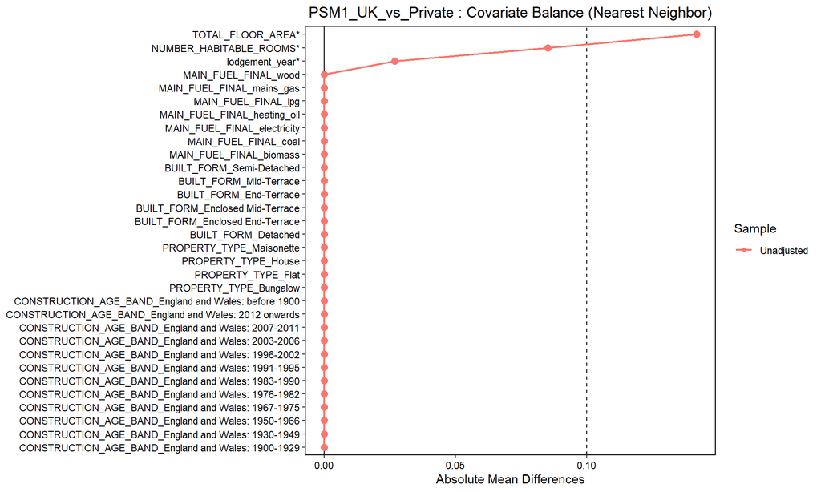

Love Plots for PSM1_UK_vs_Private

## Matched Regression Analysis for PSM1_UK_vs_Private

```r
# Run regression for analysis 1
run_regression_analysis(
  matched_data = matching_results_1$matched_data,
  outcome_var = outcome_variable,
  treatment_var = treatment_var_1,
  analysis_id = analysis_id_1,
  control_vars = regression_controls
)
```

```
##
## ## Matched Regression Analysis for PSM1_UK_vs_Private
## Treatment: treat_ukforprofit ; Control: Otherwise (within matched sample)
##
##
## ### --- Regressions WITHOUT controls ---
##
## ### Weighted regression
## OLS estimation, Dep. Var.: bad_EPC
## Observations: 53,708
## Weights: weights
## Standard-errors: Heteroskedasticity-robust
##                    Estimate Std. Error   t value  Pr(>|t|)
## (Intercept)        0.490169   0.003051 160.67794 < 2.2e-16 ***
## treat_ukforprofit -0.042005   0.004303  -9.76166 < 2.2e-16 ***
## ---
## Signif. codes:  0 '***' 0.001 '**' 0.01 '*' 0.05 '.' 0.1 ' ' 1
## RMSE: 0.498606   Adj. R2: 0.001753
##
## ### Weighted regression, with LOCAL_AUTHORITY_SUBCLASS fixed effects
## OLS estimation, Dep. Var.: bad_EPC
## Observations: 53,708
## Weights: weights
## Fixed-effects: LOCAL_AUTHORITY_SUBCLASS: 26,854
## Standard-errors: Heteroskedasticity-robust
##                    Estimate Std. Error t value  Pr(>|t|)
## treat_ukforprofit -0.042005   0.003691  -11.38 < 2.2e-16 ***
## ---
## Signif. codes:  0 '***' 0.001 '**' 0.01 '*' 0.05 '.' 0.1 ' ' 1
## RMSE: 0.302429     Adj. R2: 0.265487
##                  Within R2: 0.0048
##
##
## ### --- Regressions WITH controls (TOTAL_FLOOR_AREA, NUMBER_HABITABLE_ROOMS) ---
##
## ### Weighted regression with controls
## OLS estimation, Dep. Var.: bad_EPC
## Observations: 53,708
## Weights: weights
## Standard-errors: Heteroskedasticity-robust
```

[output cut: 8 more lines]

```
##
## ### Weighted regression with controls, with LOCAL_AUTHORITY_SUBCLASS fixed effects
## OLS estimation, Dep. Var.: bad_EPC
## Observations: 53,708
## Weights: weights
## Fixed-effects: LOCAL_AUTHORITY_SUBCLASS: 26,854
## Standard-errors: Heteroskedasticity-robust
##                         Estimate Std. Error    t value  Pr(>|t|)
## treat_ukforprofit      -0.042566   0.003733 -11.401450 < 2.2e-16 ***
## TOTAL_FLOOR_AREA        0.000119   0.000131   0.908685   0.36352
## NUMBER_HABITABLE_ROOMS -0.000958   0.004635  -0.206646   0.83629
## ---
## Signif. codes:  0 '***' 0.001 '**' 0.01 '*' 0.05 '.' 0.1 ' ' 1
## RMSE: 0.302423     Adj. R2: 0.26546
##                  Within R2: 0.004838
```

## OLS Fixed-Effects Representation for PSM1_UK_vs_Private

```r
# Run OLS representation for analysis 1
run_ols_representation(
  unmatched_data = matching_results_1$unmatched_data,
  outcome_var = outcome_variable,
  treatment_var = treatment_var_1,
  analysis_id = analysis_id_1,
  control_vars = regression_controls,
  exact_vars = common_exact_vars
)
```

```
##
## ## OLS Fixed-Effects Representation for PSM1_UK_vs_Private
##
## ### OLS with interaction of LA and individual categorical fixed effects
## OLS estimation, Dep. Var.: bad_EPC
## Observations: 134,411
## Fixed-effects: LOCAL_AUTHORITY_LABEL^CONSTRUCTION_AGE_BAND: 371,  LOCAL_AUTHORITY_LABEL^PROPERTY_TYPE: 131,  LOCAL_AUTHORITY_LABEL^BUILT_FORM: 185,  LOCAL_AUTHORITY_LABEL^MAIN_FUEL_FINAL: 172
## Standard-errors: Heteroskedasticity-robust
##                         Estimate Std. Error   t value  Pr(>|t|)
## treat_ukforprofit      -0.027888   0.002945 -9.471156 < 2.2e-16 ***
## TOTAL_FLOOR_AREA        0.000037   0.000047  0.778999   0.43598
## NUMBER_HABITABLE_ROOMS  0.001267   0.001465  0.864634   0.38724
## ---
## Signif. codes:  0 '***' 0.001 '**' 0.01 '*' 0.05 '.' 0.1 ' ' 1
## RMSE: 0.416379     Adj. R2: 0.300592
##                  Within R2: 7.317e-4
##
## ### OLS with interaction of LA and concatenated categorical fixed effect
## OLS estimation, Dep. Var.: bad_EPC
## Observations: 134,411
## Fixed-effects: LOCAL_AUTHORITY_LABEL^combined_cats: 8,543
## Standard-errors: Heteroskedasticity-robust
##                         Estimate Std. Error    t value  Pr(>|t|)
## treat_ukforprofit      -0.039802   0.003210 -12.397835 < 2.2e-16 ***
## TOTAL_FLOOR_AREA        0.000035   0.000049   0.712169   0.47636
## NUMBER_HABITABLE_ROOMS -0.000293   0.001526  -0.191964   0.84777
## ---
## Signif. codes:  0 '***' 0.001 '**' 0.01 '*' 0.05 '.' 0.1 ' ' 1
## RMSE: 0.39722     Adj. R2: 0.3246
##                 Within R2: 0.001406
```

# PSM Analysis 2: Foreign For-Profits vs. Private Landlords

Treatment: Non-UK for-profit; Control: Private landlords (no CCOD/OCOD record)

```r
analysis_id_2 <- "PSM2_Foreign_vs_Private"
treatment_var_2 <- "treat_foreignforprofit"

# Perform matching
matching_results_2 <- perform_matching(EPC_matched_combined, treatment_var_2, analysis_id_2, common_prop_score_covs, common_exact_vars)
```

— Performing Matching for: PSM2_Foreign_vs_Private — Nearest Neighbor matching complete for PSM2_Foreign_vs_Private. Matched N=4670

```r
# Generate balance tables
balance_tab_2 <- generate_balance_tables(matching_results_2, treatment_var_2, analysis_id_2, common_prop_score_covs, common_exact_vars)
```

### Balance Table for PSM2_Foreign_vs_Private (Nearest Neighbor Matching)

Balance Table (Nearest Neighbor)

|  | Type | M.0.Un | SD.0.Un | M.1.Un | SD.1.Un | Diff.Un | M.0.Adj | SD.0.Adj | M.1.Adj | SD.1.Adj | Diff.Adj |
| --- | --- | --- | --- | --- | --- | --- | --- | --- | --- | --- | --- |
| TOTAL_FLOOR_AREA | Contin. | 76.2655246 | 51.833575 | 85.6616702 | 60.398955 | 0.1555680 | NA | NA | NA | NA | NA |
| NUMBER_HABITABLE_ROOMS | Contin. | 3.1584582 | 1.536666 | 3.3798715 | 1.779640 | 0.1244146 | NA | NA | NA | NA | NA |
| lodgement_year | Contin. | 2022.3781585 | 1.214573 | 2022.3738758 | 1.221172 | -0.0035070 | NA | NA | NA | NA | NA |
| CONSTRUCTION_AGE_BAND_England and Wales: 1900-1929 | Binary | 0.2072805 | NA | 0.2072805 | NA | 0.0000000 | NA | NA | NA | NA | NA |
| CONSTRUCTION_AGE_BAND_England and Wales: 1930-1949 | Binary | 0.0895075 | NA | 0.0895075 | NA | 0.0000000 | NA | NA | NA | NA | NA |
| CONSTRUCTION_AGE_BAND_England and Wales: 1950-1966 | Binary | 0.0436831 | NA | 0.0436831 | NA | 0.0000000 | NA | NA | NA | NA | NA |
| CONSTRUCTION_AGE_BAND_England and Wales: 1967-1975 | Binary | 0.0535332 | NA | 0.0535332 | NA | 0.0000000 | NA | NA | NA | NA | NA |
| CONSTRUCTION_AGE_BAND_England and Wales: 1976-1982 | Binary | 0.0235546 | NA | 0.0235546 | NA | 0.0000000 | NA | NA | NA | NA | NA |
| CONSTRUCTION_AGE_BAND_England and Wales: 1983-1990 | Binary | 0.0269807 | NA | 0.0269807 | NA | 0.0000000 | NA | NA | NA | NA | NA |
| CONSTRUCTION_AGE_BAND_England and Wales: 1991-1995 | Binary | 0.0312634 | NA | 0.0312634 | NA | 0.0000000 | NA | NA | NA | NA | NA |
| CONSTRUCTION_AGE_BAND_England and Wales: 1996-2002 | Binary | 0.0796574 | NA | 0.0796574 | NA | 0.0000000 | NA | NA | NA | NA | NA |
| CONSTRUCTION_AGE_BAND_England and Wales: 2003-2006 | Binary | 0.1323340 | NA | 0.1323340 | NA | 0.0000000 | NA | NA | NA | NA | NA |
| CONSTRUCTION_AGE_BAND_England and Wales: 2007-2011 | Binary | 0.1224839 | NA | 0.1224839 | NA | 0.0000000 | NA | NA | NA | NA | NA |
| CONSTRUCTION_AGE_BAND_England and Wales: 2012 onwards | Binary | 0.0732334 | NA | 0.0732334 | NA | 0.0000000 | NA | NA | NA | NA | NA |
| CONSTRUCTION_AGE_BAND_England and Wales: before 1900 | Binary | 0.1164882 | NA | 0.1164882 | NA | 0.0000000 | NA | NA | NA | NA | NA |
| PROPERTY_TYPE_Bungalow | Binary | 0.0025696 | NA | 0.0025696 | NA | 0.0000000 | NA | NA | NA | NA | NA |
| PROPERTY_TYPE_Flat | Binary | 0.8235546 | NA | 0.8235546 | NA | 0.0000000 | NA | NA | NA | NA | NA |
| PROPERTY_TYPE_House | Binary | 0.1211991 | NA | 0.1211991 | NA | 0.0000000 | NA | NA | NA | NA | NA |
| PROPERTY_TYPE_Maisonette | Binary | 0.0526767 | NA | 0.0526767 | NA | 0.0000000 | NA | NA | NA | NA | NA |
| BUILT_FORM_Detached | Binary | 0.0441113 | NA | 0.0441113 | NA | 0.0000000 | NA | NA | NA | NA | NA |
| BUILT_FORM_Enclosed End-Terrace | Binary | 0.0415418 | NA | 0.0415418 | NA | 0.0000000 | NA | NA | NA | NA | NA |
| BUILT_FORM_Enclosed Mid-Terrace | Binary | 0.0496788 | NA | 0.0496788 | NA | 0.0000000 | NA | NA | NA | NA | NA |
| BUILT_FORM_End-Terrace | Binary | 0.1730193 | NA | 0.1730193 | NA | 0.0000000 | NA | NA | NA | NA | NA |
| BUILT_FORM_Mid-Terrace | Binary | 0.5700214 | NA | 0.5700214 | NA | 0.0000000 | NA | NA | NA | NA | NA |
| BUILT_FORM_Semi-Detached | Binary | 0.1216274 | NA | 0.1216274 | NA | 0.0000000 | NA | NA | NA | NA | NA |
| MAIN_FUEL_FINAL_electricity | Binary | 0.2642398 | NA | 0.2642398 | NA | 0.0000000 | NA | NA | NA | NA | NA |
| MAIN_FUEL_FINAL_heating_oil | Binary | 0.0051392 | NA | 0.0051392 | NA | 0.0000000 | NA | NA | NA | NA | NA |
| MAIN_FUEL_FINAL_lpg | Binary | 0.0017131 | NA | 0.0017131 | NA | 0.0000000 | NA | NA | NA | NA | NA |
| MAIN_FUEL_FINAL_mains_gas | Binary | 0.7284797 | NA | 0.7284797 | NA | 0.0000000 | NA | NA | NA | NA | NA |
| MAIN_FUEL_FINAL_wood | Binary | 0.0004283 | NA | 0.0004283 | NA | 0.0000000 | NA | NA | NA | NA | NA |

```r
# Generate Love plots
generate_love_plots(balance_tab_2, analysis_id_2)
```

## Love Plot for PSM2_Foreign_vs_Private

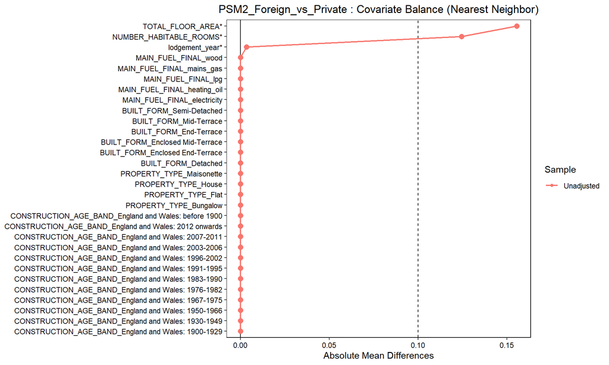

Love Plots for PSM2_Foreign_vs_Private

## Matched Regression Analysis for PSM2_Foreign_vs_Private

```r
# Run regression for analysis 2
run_regression_analysis(
  matched_data = matching_results_2$matched_data,
  outcome_var = outcome_variable,
  treatment_var = treatment_var_2,
  analysis_id = analysis_id_2,
  control_vars = regression_controls
)
```

```
##
## ## Matched Regression Analysis for PSM2_Foreign_vs_Private
## Treatment: treat_foreignforprofit ; Control: Otherwise (within matched sample)
##
##
## ### --- Regressions WITHOUT controls ---
##
## ### Weighted regression
## OLS estimation, Dep. Var.: bad_EPC
## Observations: 4,670
## Weights: weights
## Standard-errors: Heteroskedasticity-robust
##                         Estimate Std. Error  t value   Pr(>|t|)
## (Intercept)             0.305782   0.009537 32.06329  < 2.2e-16 ***
## treat_foreignforprofit -0.047537   0.013154 -3.61398 0.00030471 ***
## ---
## Signif. codes:  0 '***' 0.001 '**' 0.01 '*' 0.05 '.' 0.1 ' ' 1
## RMSE: 0.449351   Adj. R2: 0.002577
##
## ### Weighted regression, with LOCAL_AUTHORITY_SUBCLASS fixed effects
## OLS estimation, Dep. Var.: bad_EPC
## Observations: 4,670
## Weights: weights
## Fixed-effects: LOCAL_AUTHORITY_SUBCLASS: 2,335
## Standard-errors: Heteroskedasticity-robust
##                         Estimate Std. Error  t value   Pr(>|t|)
## treat_foreignforprofit -0.047537   0.011184 -4.25036 2.2182e-05 ***
## ---
## Signif. codes:  0 '***' 0.001 '**' 0.01 '*' 0.05 '.' 0.1 ' ' 1
## RMSE: 0.270166     Adj. R2: 0.278895
##                  Within R2: 0.007681
##
##
## ### --- Regressions WITH controls (TOTAL_FLOOR_AREA, NUMBER_HABITABLE_ROOMS) ---
##
## ### Weighted regression with controls
## OLS estimation, Dep. Var.: bad_EPC
## Observations: 4,670
## Weights: weights
## Standard-errors: Heteroskedasticity-robust
```

[output cut: 8 more lines]

```
##
## ### Weighted regression with controls, with LOCAL_AUTHORITY_SUBCLASS fixed effects
## OLS estimation, Dep. Var.: bad_EPC
## Observations: 4,670
## Weights: weights
## Fixed-effects: LOCAL_AUTHORITY_SUBCLASS: 2,335
## Standard-errors: Heteroskedasticity-robust
##                         Estimate Std. Error   t value   Pr(>|t|)
## treat_foreignforprofit -0.050498   0.011486 -4.396552 1.1492e-05 ***
## TOTAL_FLOOR_AREA        0.000106   0.000324  0.326629 7.4398e-01
## NUMBER_HABITABLE_ROOMS  0.008872   0.009060  0.979247 3.2756e-01
## ---
## Signif. codes:  0 '***' 0.001 '**' 0.01 '*' 0.05 '.' 0.1 ' ' 1
## RMSE: 0.270053     Adj. R2: 0.278881
##                  Within R2: 0.008513
```

## OLS Fixed-Effects Representation for PSM2_Foreign_vs_Private

```r
# Run OLS representation for analysis 2
run_ols_representation(
  unmatched_data = matching_results_2$unmatched_data,
  outcome_var = outcome_variable,
  treatment_var = treatment_var_2,
  analysis_id = analysis_id_2,
  control_vars = regression_controls,
  exact_vars = common_exact_vars
)
```

```
##
## ## OLS Fixed-Effects Representation for PSM2_Foreign_vs_Private
##
## ### OLS with interaction of LA and individual categorical fixed effects
## OLS estimation, Dep. Var.: bad_EPC
## Observations: 87,748
## Fixed-effects: LOCAL_AUTHORITY_LABEL^CONSTRUCTION_AGE_BAND: 371,  LOCAL_AUTHORITY_LABEL^PROPERTY_TYPE: 128,  LOCAL_AUTHORITY_LABEL^BUILT_FORM: 182,  LOCAL_AUTHORITY_LABEL^MAIN_FUEL_FINAL: 164
## Standard-errors: Heteroskedasticity-robust
##                         Estimate Std. Error   t value Pr(>|t|)
## treat_foreignforprofit -0.017854   0.008009 -2.229294 0.025797 *
## TOTAL_FLOOR_AREA        0.000037   0.000052  0.706134 0.480107
## NUMBER_HABITABLE_ROOMS  0.001131   0.001682  0.672291 0.501400
## ---
## Signif. codes:  0 '***' 0.001 '**' 0.01 '*' 0.05 '.' 0.1 ' ' 1
## RMSE: 0.427722     Adj. R2: 0.255219
##                  Within R2: 7.262e-5
##
## ### OLS with interaction of LA and concatenated categorical fixed effect
## OLS estimation, Dep. Var.: bad_EPC
## Observations: 87,748
## Fixed-effects: LOCAL_AUTHORITY_LABEL^combined_cats: 7,151
## Standard-errors: Heteroskedasticity-robust
##                         Estimate Std. Error   t value   Pr(>|t|)
## treat_foreignforprofit -0.056920   0.009297 -6.122131 9.2757e-10 ***
## TOTAL_FLOOR_AREA        0.000027   0.000054  0.499926 6.1713e-01
## NUMBER_HABITABLE_ROOMS -0.001053   0.001768 -0.595705 5.5137e-01
## ---
## Signif. codes:  0 '***' 0.001 '**' 0.01 '*' 0.05 '.' 0.1 ' ' 1
## RMSE: 0.407231     Adj. R2: 0.272021
##                  Within R2: 4.105e-4
```